# Untitled

Roberto Álvarez

2024-03-20

# 1 Introduction

The datasets are from the red and white variants of Portuguese “Vinho Verde” wine. This particular wine holds significance in the viticulture landscape, showcasing distinctive physicochemical and sensory attributes that contribute to its quality and character. For further insights into Vinho Verde, interested individuals may refer to the official website at http://www.vinhoverde.pt/en/.

Privacy and logistical constraints have led to the availability of only physicochemical (input) and sensory (output) variables in these datasets. Notably, information regarding grape types, wine brand, selling prices, and other proprietary details remains undisclosed. Consequently, the focus lies squarely on understanding the features that define the quality of Vinho Verde wine.

The objective of this analysis is:

1. **Quality Assessment**: Develop predictive models to assess the quality of Vinho Verde wines based on their physicochemical and sensory attributes.
2. **Cost-Sensitive Evaluation**: Go beyond traditional evaluation metrics by considering cost-sensitive approaches that weigh the financial implications of prediction errors.

By exploting classification techniques, we aim to unravel the intricate relationship between wine attributes and quality perception. Furthermore, through cost-sensitive evaluation, we seek to optimize model performance while considering the economic consequences associated with misclassifications.

In the following sections, we delve into exploratory data analysis, model development, and evaluation to derive actionable insights that can inform decision-making processes within the viticulture industry. Ultimately, our attempt is to enhance wine quality assessment practices, boost consumer satisfaction, and stimulate innovation in the production of Vinho Verde wines.

# 2 Load useful libraries

```r
library(tidyverse)
library(skimr)
library(mice)
library(VIM)
library(GGally)
library(MASS)
library(glmnet)
library(e1071)
library(rpart)
library(pROC)
library(class)
library(VGAM)
library(gridExtra)
library(ggplot2)
library(patchwork)
library(reshape2)
library(viridis)
library(knitr)
library(forcats)
library(caret)
library(randomForest)
library(gbm)
library(neuralnet)
```

# 3 Load and explore the data set

We load both datasets and merge them together:

```r
# Read the white wine dataset
data_white <- read.csv("winequality-white.csv", header = TRUE, sep = ";")

# Read the red wine dataset
data_red <- read.csv("winequality-red.csv", header = TRUE, sep = ";")

# Add a new variable indicating the origin of each observation
data_white$Type <- "white"
data_red$Type <- "red"

# Convert the "Type" variable to a factor
data_white$Type <- factor(data_white$Type)
data_red$Type <- factor(data_red$Type)

# Combine the two datasets vertically
data <- rbind(data_white, data_red)

# Check the structure of the combined dataset
glimpse(data)
```

```
## Rows: 6,497
## Columns: 13
## $ fixed.acidity        <dbl> 7.0, 6.3, 8.1, 7.2, 7.2, 8.1, 6.2, 7.0, 6.3, 8.1,…
## $ volatile.acidity     <dbl> 0.27, 0.30, 0.28, 0.23, 0.23, 0.28, 0.32, 0.27, 0…
## $ citric.acid          <dbl> 0.36, 0.34, 0.40, 0.32, 0.32, 0.40, 0.16, 0.36, 0…
## $ residual.sugar       <dbl> 20.70, 1.60, 6.90, 8.50, 8.50, 6.90, 7.00, 20.70,…
## $ chlorides            <dbl> 0.045, 0.049, 0.050, 0.058, 0.058, 0.050, 0.045, …
## $ free.sulfur.dioxide  <dbl> 45, 14, 30, 47, 47, 30, 30, 45, 14, 28, 11, 17, 1…
## $ total.sulfur.dioxide <dbl> 170, 132, 97, 186, 186, 97, 136, 170, 132, 129, 6…
## $ density              <dbl> 1.0010, 0.9940, 0.9951, 0.9956, 0.9956, 0.9951, 0…
## $ pH                   <dbl> 3.00, 3.30, 3.26, 3.19, 3.19, 3.26, 3.18, 3.00, 3…
## $ sulphates            <dbl> 0.45, 0.49, 0.44, 0.40, 0.40, 0.44, 0.47, 0.45, 0…
## $ alcohol              <dbl> 8.8, 9.5, 10.1, 9.9, 9.9, 10.1, 9.6, 8.8, 9.5, 11…
## $ quality              <int> 6, 6, 6, 6, 6, 6, 6, 6, 6, 6, 5, 5, 5, 7, 5, 7, 6…
## $ Type                 <fct> white, white, white, white, white, white, white, …
```

Output Variable:

- **Quality (Score between 0 and 10):**
  - Description: Represents the quality of the wine on a scale from 0 (lowest) to 10 (highest).

Lets get insights from the available data.

```r
summary(data)
```

```
##  fixed.acidity    volatile.acidity  citric.acid     residual.sugar
##  Min.   : 3.800   Min.   :0.0800   Min.   :0.0000   Min.   : 0.600
##  1st Qu.: 6.400   1st Qu.:0.2300   1st Qu.:0.2500   1st Qu.: 1.800
##  Median : 7.000   Median :0.2900   Median :0.3100   Median : 3.000
##  Mean   : 7.215   Mean   :0.3397   Mean   :0.3186   Mean   : 5.443
##  3rd Qu.: 7.700   3rd Qu.:0.4000   3rd Qu.:0.3900   3rd Qu.: 8.100
##  Max.   :15.900   Max.   :1.5800   Max.   :1.6600   Max.   :65.800
##    chlorides       free.sulfur.dioxide total.sulfur.dioxide    density
##  Min.   :0.00900   Min.   :  1.00      Min.   :  6.0        Min.   :0.9871
##  1st Qu.:0.03800   1st Qu.: 17.00      1st Qu.: 77.0        1st Qu.:0.9923
##  Median :0.04700   Median : 29.00      Median :118.0        Median :0.9949
##  Mean   :0.05603   Mean   : 30.53      Mean   :115.7        Mean   :0.9947
##  3rd Qu.:0.06500   3rd Qu.: 41.00      3rd Qu.:156.0        3rd Qu.:0.9970
##  Max.   :0.61100   Max.   :289.00      Max.   :440.0        Max.   :1.0390
##        pH          sulphates         alcohol         quality         Type
##  Min.   :2.720   Min.   :0.2200   Min.   : 8.00   Min.   :3.000   white:4898
##  1st Qu.:3.110   1st Qu.:0.4300   1st Qu.: 9.50   1st Qu.:5.000   red  :1599
##  Median :3.210   Median :0.5100   Median :10.30   Median :6.000
##  Mean   :3.219   Mean   :0.5313   Mean   :10.49   Mean   :5.818
##  3rd Qu.:3.320   3rd Qu.:0.6000   3rd Qu.:11.30   3rd Qu.:6.000
##  Max.   :4.010   Max.   :2.0000   Max.   :14.90   Max.   :9.000
```

1. **Fixed Acidity:** The mean value is 7.215 g/dm³, indicating the average total acidity in the wine. The range extends from 3.8 g/dm³ to 15.9 g/dm³.
2. **Volatile Acidity:** The mean value is 0.3397 g/dmÂ³, representing the average amount of acetic acid in the wine. Lower values preferred to avoid a vinegary taste.
3. **Citric Acid:** The mean citric acid content is 0.3186 g/dm³, with values ranging from 0 to 1.66 g/dm³.
4. **Residual Sugar:** The mean residual sugar level is 5.443 g/dmÂ³, indicating the amount of sugar remaining after fermentation. This measure helps classify wines as sweet or dry.
5. **Chlorides:** The mean chloride content is 0.05603 g/dm³, with values ranging from 0.009 g/dm³ to 0.611 g/dm³.
6. **Free Sulfur Dioxide:** The mean free sulfur dioxide concentration is 30.53 mg/dm³, with values ranging from 1 mg/dm³ to 289 mg/dm³.
7. **Total Sulfur Dioxide:** The mean total sulfur dioxide concentration is 115.7 mg/dm³, with values ranging from 6 mg/dm³ to 440 mg/dm³.
8. **Density:** The mean density is 0.9947 g/cm³, with values ranging from 0.9871 g/cm³ to 1.039 g/cm³.
9. **pH:** The mean pH value is 3.219, indicating the wine’s acidity or alkalinity. It falls within the range that most wines have, that is of 3 to 4 on the pH scale.
10. **Sulphates:** The mean sulphate content is 0.5313 g/dm³, with values ranging from 0.22 g/dm³ to 2 g/dm³.
11. **Alcohol:** The mean alcohol content is 10.49% by volume, with values ranging from 8% to 14.9%. Alcohol content is a crucial factor influencing the wine’s taste and body.
12. **Quality:** The wine quality ranges from 3 to 9, with a mean value of 5.818. This variable represents the overall perceived quality of the wine.
13. **Type:** Indicates the type of wine, with 4898 white wine samples and 1599 red wine samples in the dataset.

## 3.1 Split Data

Split data into training and testing sets

```r
# Splitting the data into training and testing sets
in_train <- createDataPartition(data$quality, p = 0.6, list = FALSE)
training <- data[in_train,]
testing <- data[-in_train,]

# Checking the number of rows in the training and testing sets
print(paste("Number of rows in training ", nrow(training)))
```

```
## [1] "Number of rows in training  3900"
```

```r
print(paste("Number of rows in testing ", nrow(testing)))
```

```
## [1] "Number of rows in testing  2597"
```

# 4 Data cleaning and Feature Engineering

We check for duplicate values in both train and test:

```r
# Checking for duplicates in the training set
duplicated_rows_training <- duplicated(training)
any(duplicated_rows_training)
```

```
## [1] TRUE
```

```r
# Checking for duplicates in the testing set
duplicated_rows_testing <- duplicated(testing)
any(duplicated_rows_testing)
```

```
## [1] TRUE
```

There are duplicate values in the dataset.We have to remove them:

```r
# Remove duplicated rows from the training set
training <- unique(training)

# Remove duplicated rows from the testing set
testing <- unique(testing)
```

## 4.1 Missing values

For the data cleaning lets start first checking if there are any missing values in the training or testing sets:

```r
# Check for missing values in the training set
missing_values_train <- colSums(is.na(training))
# Print the number of missing values for each variable in the training set
print(missing_values_train)
```

```
##        fixed.acidity     volatile.acidity          citric.acid
##                    0                    0                    0
##       residual.sugar            chlorides  free.sulfur.dioxide
##                    0                    0                    0
## total.sulfur.dioxide              density                   pH
##                    0                    0                    0
##            sulphates              alcohol              quality
##                    0                    0                    0
##                 Type
##                    0
```

```r
# Check for missing values in the training set
missing_values_test<- colSums(is.na(testing))
# Print the number of missing values for each variable in the training set
print(missing_values_test)
```

```
##        fixed.acidity     volatile.acidity          citric.acid
##                    0                    0                    0
##       residual.sugar            chlorides  free.sulfur.dioxide
##                    0                    0                    0
## total.sulfur.dioxide              density                   pH
##                    0                    0                    0
##            sulphates              alcohol              quality
##                    0                    0                    0
##                 Type
##                    0
```

There are no missing values neither in the training nor the testing datasets.

# 5 EDA

Following the data cleaning process, we proceed with the Exploratory Data Analysis (EDA) to gain insights into the distribution and characteristics of our variables.

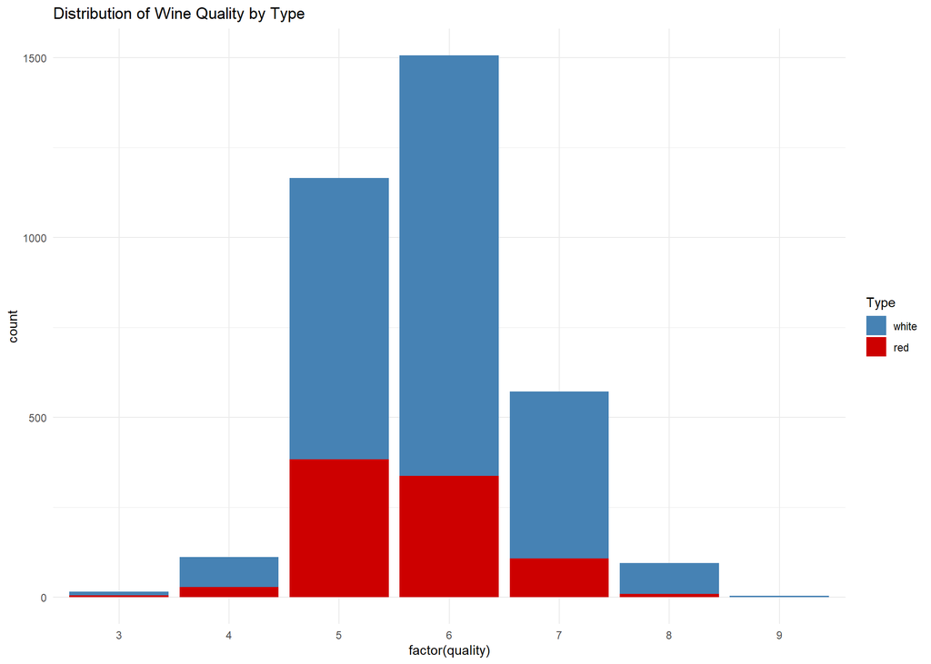

The distribution of wine quality by type shows a concentration around levels 5, 6, and 7, with white wine exhibiting a higher count for those levels compared to red wine.

## 5.1 Balance classes

We first check the proportion of the levels in quality in order to know where to divide the quality into 2 categories.

```r
# Checking the distribution of 'Quality' in the training set
table(training$quality) / length(training$quality)
```

```
##
##            3            4            5            6            7            8
## 0.0043252595 0.0320069204 0.3362168397 0.4342560554 0.1649365629 0.0273933103
##            9
## 0.0008650519
```

We then proceed to divide the quality scores into 2 categories to do classification, from lower than 6 will be classified as “Regular” and 6 or higher as “Premium”.

```r
# Transformation:
# Categorize quality as "Regular" or "Premium"
training$quality <- ifelse(training$quality < 6, "Regular", "Premium")
# Convert 'quality' to a factor variable
training$quality <- factor(training$quality, levels = c("Regular", "Premium"))
# Similarly for testing data
testing$quality <- ifelse(testing$quality < 6, "Regular", "Premium")
testing$quality <- factor(testing$quality, levels = c("Regular", "Premium"))
```

```r
# Checking the distribution of 'quality' in the training set
table(training$quality) / length(training$quality)
```

```
##
##  Regular  Premium
## 0.372549 0.627451
```

This is the Naive classifier, 62.74 % Premium, which indicates high quality wine and 37.25% Regular, clearly states that is an unbalanced dataset.

## 5.2 Distributions

To gain an overall visualization of our data we perfom a ggpairs visualization:

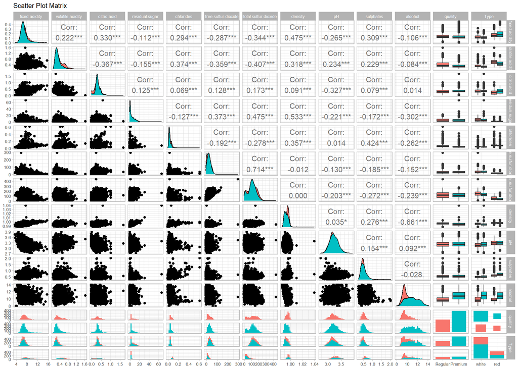

To get a higher a clear interpretation we create the density plots:

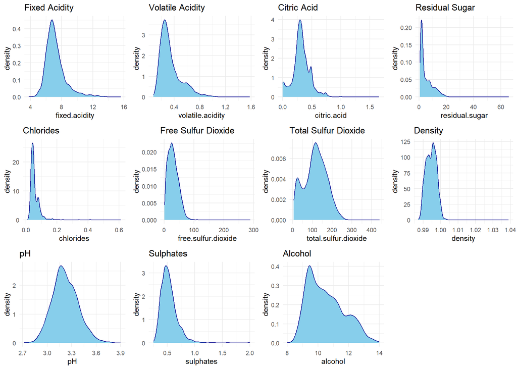

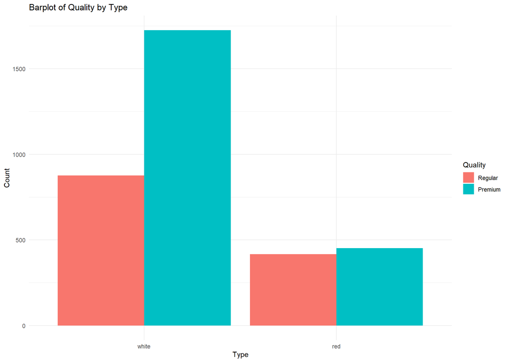

The barplot of quality by Type shows that for red wine, quality classes are mostly balance, however, for white wine, the Premium class stands out.

After having analyzed the distributions, we proceeded to examine the relationships between different pairs of numerical variables that in the ggpairs seemed to present outliers:

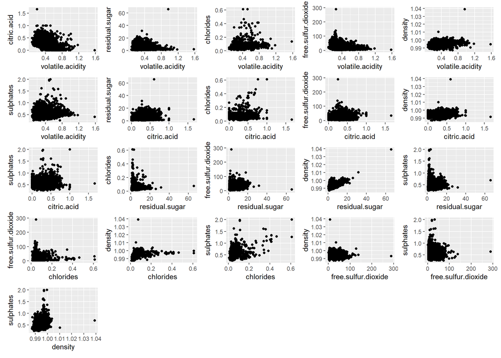

From the density plots, outliers are evident for several variables. Notably, for “volatile acidity,” values exceeding 1.4 g/dm³ appear to be outliers. Similarly, for “citric acid,” values above 1 g/dm³ and for “residual sugar,” values surpassing 30 g/dm³ also appear to be outliers. These extreme values are likely to be noise and may potentially distort our analysis. Therefore, we will remove these outliers to ensure the reliability of our future analyses.

## 5.3 Correlation

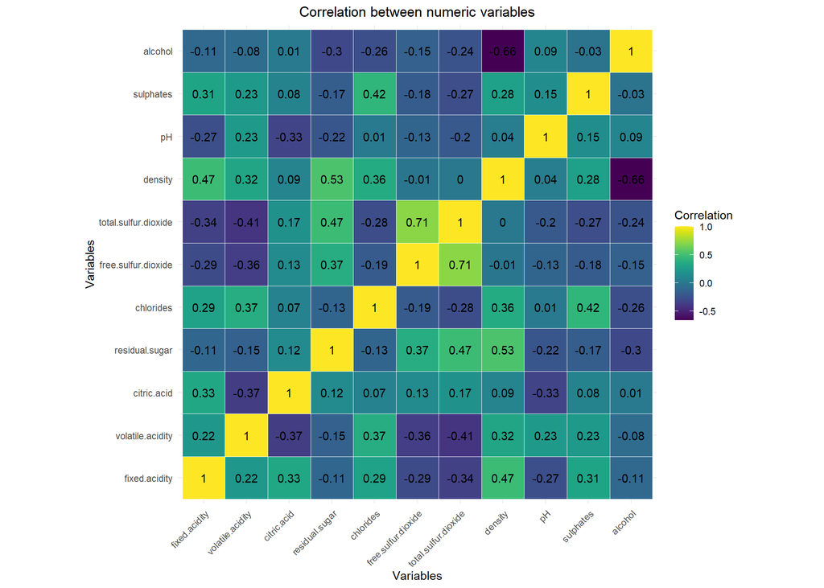

After analyzing the distributions and identifying outliers, the next step involves examining the correlation matrix of the numerical variables. This correlation heatmap provides insights into the relationships between the features in the training dataset. By detecting multicollinearity among variables, we can assess how strongly predictors are correlated with each other. In our analysis, we observe that there are no high correlations between most variables, indicating low multicollinearity. However, there is a notable correlation between the variables “free sulfur dioxide” and “total sulfur dioxide,” with a correlation coefficient of 0.71. This suggests a stronger relationship between these two variables compared to others, which is expected given their similar nature.

In this analysis, we examine the correlation between wine quality and other variables in the dataset. The variable “quality_numeric” represents the quality of wine, with a value of 1 indicating good quality and 0 indicating otherwise.

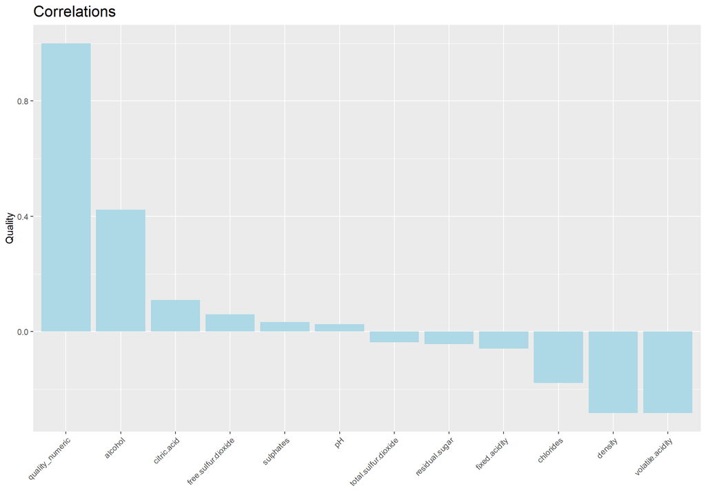

Upon evaluating the correlation coefficients between wine quality and the other variables, we find that the most significant correlation exists with the variable “alcohol.” This suggests that alcohol content has a strong relationship with wine quality, indicating that wines with higher alcohol content tend to be associated with better quality.

### 5.3.1 Most important variable

We make plots to visualize the relationship between the most important variable, alcohol, and quality in the training set.

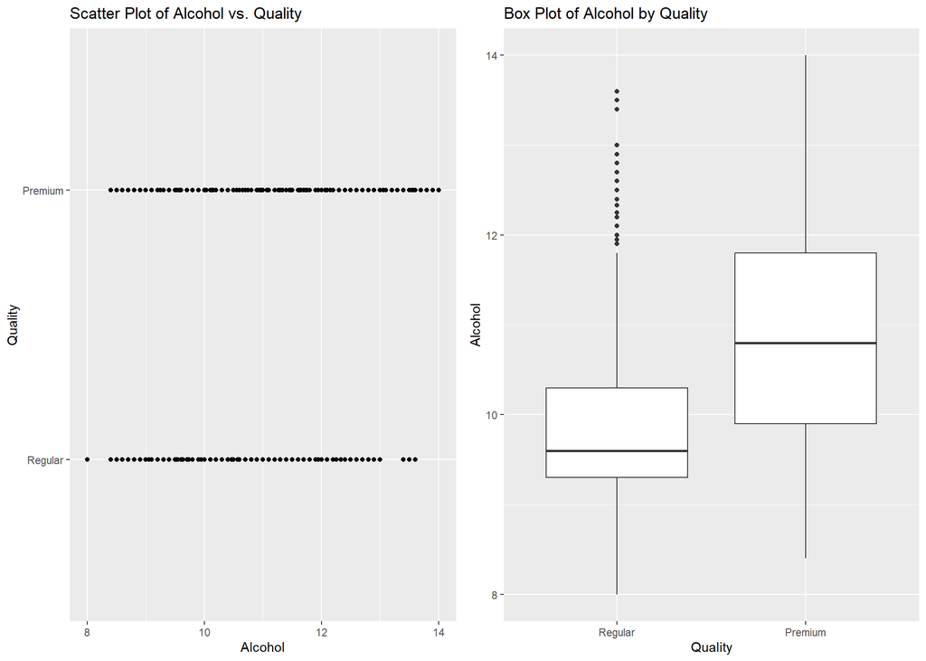

## 5.4 Removing outliers

We remove the outliers mentioned earlier:

```r
# Define conditions to filter out outliers for training data
condition_train <- training$volatile.acidity <= 1.4 &
                   training$citric.acid <= 1 &
                   training$residual.sugar <= 30 &
                   training$chlorides <= 0.5 &
                   training$free.sulfur.dioxide <= 125 &
                   training$density <= 1.01 &
                   training$sulphates <= 1.75 &
                   !(training$quality == "Regular" & training$alcohol > 14)

# Filter the training data using the condition
training_2 <- training[condition_train, ]

# Define conditions to filter out outliers for testing data
condition_test <- testing$volatile.acidity <= 1.4 &
                  testing$citric.acid <= 1 &
                  testing$residual.sugar <= 30 &
                  testing$chlorides <= 0.5 &
                  testing$free.sulfur.dioxide <= 125 &
                  testing$density <= 1.01 &
                  testing$sulphates <= 1.75 &
                  !(testing$quality == "Regular" & testing$alcohol > 14)

# Filter the testing data using the condition
testing_2 <- testing[condition_test, ]
```

## 5.5 Transformations

After exploring various transformation methods to address positive skewness in the ‘residual sugar’ and ‘alcohol’ variables, we attempted both natural logarithm and base 2 logarithm transformations on these variables. However, we observed that these transformations did not significantly improve the skewness or achieve a more symmetrical distribution. Hence, we chose not to apply transformations to these variables due to their distribution characteristics.

We also attempted a squared transformation on the ‘total sulfur dioxide’ variable, but this did not provide significant improvements in the variable’s distribution.

Additionally, we centered the ‘chlorides,’ ‘free sulfur dioxide,’ ‘density,’ and ‘sulphates’ variables, but we did not observe substantial improvements in their distributions after centering.

Finally, we standardized the ‘chlorides,’ ‘free sulfur dioxide,’ ‘density,’ and ‘sulphates’ variables. However, these transformations did not yield significant improvements in the variables’ distributions.

```r
# Apply log transformation to residual.sugar and alcohol and replace original columns
#training_2$residual.sugar <- log(training_2$residual.sugar)
#training_2$alcohol <- log(training_2$alcohol)
#training_2[, c( "residual.sugar")] <- log2(training_2[, c( "residual.sugar")] + 1)
#training_2[, c( "alcohol")] <- log2(training_2[, c( "alcohol")] + 1)

# Apply x^2 transformation to total.sulfur.dioxide
#training_2$total.sulfur.dioxide <- training_2$total.sulfur.dioxide^2

# Apply other transformations if needed
# For example, centering chlorides, free.sulfur.dioxide, density, and sulphates
# Center variables
#training_2$chlorides <- training_2$chlorides - mean(training_2$chlorides)
#training_2$free.sulfur.dioxide <- training_2$free.sulfur.dioxide - mean(training_2$free.sulfur.dioxide)
#training_2$density <- training_2$density - mean(training_2$density)
#training_2$sulphates <- training_2$sulphates - mean(training_2$sulphates)

# Standardize variables
#training_2$chlorides <- scale(training_2$chlorides)
#training_2$free.sulfur.dioxide <- scale(training_2$free.sulfur.dioxide)
#training_2$density <- scale(training_2$density)
#training_2$sulphates <- scale(training_2$sulphates)
```

Final plot of distributions by class after EDA preprocessing is presented below. Each density plot represents a different variable, colored by the class variable “quality” to visualize the distribution for both Regular and Premium cases :

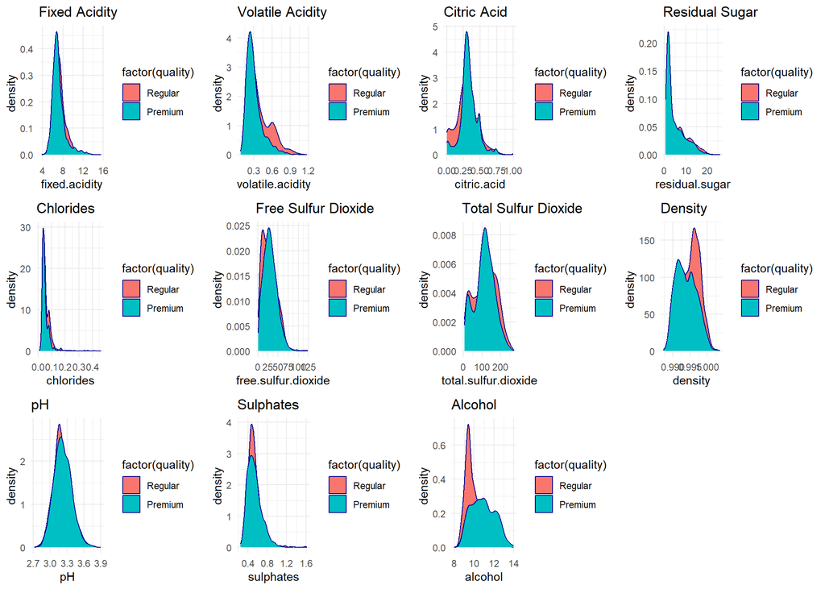

This visualization allows us to observe how the distributions of these variables are after the preprocessing and also how they differ between Regular and Premium wines, we can see that for most of the variables distribution among classes is pretty similar, only differing in “density”, “alcohol” and “sulphates” variables, where in both cases there is a higher density for Regular wines.

# 6 ML MODELS

In contrast to statistical tools, machine learning algorithms do not rely on assumptions about the underlying data distribution. This characteristic makes machine learning models more adaptable to real-world scenarios, thereby enabling them to make better predictions. However, this improved predictive capability often comes at the expense of providing less interpretable explanations.

In our analysis, we will explore various types of machine learning models, including KNN (K-Nearest Neighbors), SVM (Support Vector Machines), Random Forest, Gradient Boosting, and Neural Networks. The primary criterion for selecting the best model will be based on accuracy.

We are employing the Caret package for all our models, utilizing its functionalities for evaluating performance and estimating model performance from a training set. Each model will be trained using 1 repeat of 5-fold cross-validation to ensure robustness and generalizability.

We create the Caret control that will be used in all the models:

```r
ctrl <- trainControl(method = "cv", number = 5,
                     classProbs = TRUE,
                     verboseIter=FALSE)
```

## 6.1 KNN with Caret

```r
knnFit <- train(quality ~ .,
                method = "knn",
                data = training_2,
                preProcess = c("center", "scale"),
                tuneLength = 7, # tuning the KNN model.
                metric = "Accuracy",
                trControl = ctrl
                )
print(knnFit)
```

```
## k-Nearest Neighbors
##
## 3457 samples
##   12 predictor
##    2 classes: 'Regular', 'Premium'
##
## Pre-processing: centered (12), scaled (12)
## Resampling: Cross-Validated (5 fold)
## Summary of sample sizes: 2765, 2765, 2766, 2766, 2766
## Resampling results across tuning parameters:
##
##   k   Accuracy   Kappa
##    5  0.7361753  0.4215410
##    7  0.7480388  0.4470066
##    9  0.7448621  0.4386504
##   11  0.7535389  0.4608005
##   13  0.7538283  0.4593826
##   15  0.7552751  0.4617790
##   17  0.7558565  0.4594020
##
## Accuracy was used to select the optimal model using the largest value.
## The final value used for the model was k = 17.
```

### 6.1.1 KNN Predictions

```r
knnPred = predict(knnFit, testing_2)

confusionMatrix(knnPred,testing_2$quality)
```

```
## Confusion Matrix and Statistics
##
##           Reference
## Prediction Regular Premium
##    Regular     479     224
##    Premium     391    1278
##
##                Accuracy : 0.7407
##                  95% CI : (0.7226, 0.7583)
##     No Information Rate : 0.6332
##     P-Value [Acc > NIR] : < 2.2e-16
##
##                   Kappa : 0.4183
##
##  Mcnemar's Test P-Value : 2.175e-11
##
##             Sensitivity : 0.5506
##             Specificity : 0.8509
##          Pos Pred Value : 0.6814
##          Neg Pred Value : 0.7657
##              Prevalence : 0.3668
##          Detection Rate : 0.2019
##    Detection Prevalence : 0.2964
##       Balanced Accuracy : 0.7007
##
##        'Positive' Class : Regular
##
```

## 6.2 SVM with Caret

Support Vector Machines model:

```r
svmFit <- train(quality ~ ., method = "svmRadial",
                data = training_2,
                preProcess = c("center", "scale"),
                tuneGrid = expand.grid(C = c(.25, .5, 1),
                                      sigma = c(0.01,.05)), #for the project a higher grid, a higher grid implies a better profit
                metric = "Accuracy",
                trControl = ctrl
                )
print(svmFit)
```

```
## Support Vector Machines with Radial Basis Function Kernel
##
## 3457 samples
##   12 predictor
##    2 classes: 'Regular', 'Premium'
##
## Pre-processing: centered (12), scaled (12)
## Resampling: Cross-Validated (5 fold)
## Summary of sample sizes: 2766, 2765, 2766, 2766, 2765
## Resampling results across tuning parameters:
##
##   C     sigma  Accuracy   Kappa
##   0.25  0.01   0.7402408  0.4289445
##   0.25  0.05   0.7547004  0.4590419
##   0.50  0.01   0.7466062  0.4414590
##   0.50  0.05   0.7613528  0.4748494
##   1.00  0.01   0.7526785  0.4551517
##   1.00  0.05   0.7659809  0.4844279
##
## Accuracy was used to select the optimal model using the largest value.
## The final values used for the model were sigma = 0.05 and C = 1.
```

### 6.2.1 SVM Predictions

```r
svmPred = predict(svmFit, testing_2)
confusionMatrix(svmPred,testing_2$quality)
```

```
## Confusion Matrix and Statistics
##
##           Reference
## Prediction Regular Premium
##    Regular     503     195
##    Premium     367    1307
##
##                Accuracy : 0.7631
##                  95% CI : (0.7454, 0.7801)
##     No Information Rate : 0.6332
##     P-Value [Acc > NIR] : < 2.2e-16
##
##                   Kappa : 0.4678
##
##  Mcnemar's Test P-Value : 5.465e-13
##
##             Sensitivity : 0.5782
##             Specificity : 0.8702
##          Pos Pred Value : 0.7206
##          Neg Pred Value : 0.7808
##              Prevalence : 0.3668
##          Detection Rate : 0.2121
##    Detection Prevalence : 0.2943
##       Balanced Accuracy : 0.7242
##
##        'Positive' Class : Regular
##
```

## 6.3 Advanced Decision Trees

### 6.3.1 C5.0

Advanced DT model, somehow it’s a boosting approach:

```r
# Define the grid of parameters for tuning
grid_c50 <- expand.grid(.winnow = c(TRUE, FALSE),  # Decision whether to use winnowing or not
                         .trials = c(1, 4),         # Number of trials for C5.0 algorithm (limited to avoid warning)
                         .model = "tree")          # Model to be used

# Train the model using cross-validation
fit.c50 <- train(quality ~ .,
                 data = training_2,
                 method = "C5.0",
                 metric = "Accuracy",
                 tuneGrid = grid_c50,
                 trControl = ctrl)

# Print the results of the trained model
print(fit.c50)
```

```
## C5.0
##
## 3457 samples
##   12 predictor
##    2 classes: 'Regular', 'Premium'
##
## No pre-processing
## Resampling: Cross-Validated (5 fold)
## Summary of sample sizes: 2765, 2766, 2766, 2765, 2766
## Resampling results across tuning parameters:
##
##   winnow  trials  Accuracy   Kappa
##   FALSE   1       0.7347419  0.4230804
##   FALSE   4       0.7425508  0.4397959
##    TRUE   1       0.7396602  0.4321595
##    TRUE   4       0.7457371  0.4398888
##
## Tuning parameter 'model' was held constant at a value of tree
## Accuracy was used to select the optimal model using the largest value.
## The final values used for the model were trials = 4, model = tree and winnow
##  = TRUE.
```

#### 6.3.1.1 DT Predictions

```r
c50.pred <- predict(fit.c50, newdata=testing_2)
confusionMatrix(c50.pred, testing_2$quality)
```

```
## Confusion Matrix and Statistics
##
##           Reference
## Prediction Regular Premium
##    Regular     489     226
##    Premium     381    1276
##
##                Accuracy : 0.7441
##                  95% CI : (0.726, 0.7616)
##     No Information Rate : 0.6332
##     P-Value [Acc > NIR] : < 2.2e-16
##
##                   Kappa : 0.4276
##
##  Mcnemar's Test P-Value : 4.087e-10
##
##             Sensitivity : 0.5621
##             Specificity : 0.8495
##          Pos Pred Value : 0.6839
##          Neg Pred Value : 0.7701
##              Prevalence : 0.3668
##          Detection Rate : 0.2062
##    Detection Prevalence : 0.3014
##       Balanced Accuracy : 0.7058
##
##        'Positive' Class : Regular
##
```

## 6.4 Random Forest with Caret

Now train a RF using Caret with the specific metric:

```r
rf.train <- train(quality ~.,
                  method = "rf",
                  data = training_2,
                  preProcess = c("center", "scale"),
                  ntree = 200,
                  cutoff=c(0.7,0.3),
                  tuneGrid = expand.grid(mtry=c(6,8,10)),
                  metric = "Accuracy",
                  maximize = F,
                  trControl = ctrl)
```

### 6.4.1 RF Prediction:

```r
rfPred <-predict(rf.train, newdata=testing_2)
confusionMatrix(factor(rfPred), testing_2$quality)
```

```
## Confusion Matrix and Statistics
##
##           Reference
## Prediction Regular Premium
##    Regular     387      62
##    Premium     483    1440
##
##                Accuracy : 0.7702
##                  95% CI : (0.7528, 0.787)
##     No Information Rate : 0.6332
##     P-Value [Acc > NIR] : < 2.2e-16
##
##                   Kappa : 0.4493
##
##  Mcnemar's Test P-Value : < 2.2e-16
##
##             Sensitivity : 0.4448
##             Specificity : 0.9587
##          Pos Pred Value : 0.8619
##          Neg Pred Value : 0.7488
##              Prevalence : 0.3668
##          Detection Rate : 0.1632
##    Detection Prevalence : 0.1893
##       Balanced Accuracy : 0.7018
##
##        'Positive' Class : Regular
##
```

## 6.5 Gradient Boosting

Let’s try now XGBoost:

```r
xgb_grid = expand.grid(
  nrounds = c(500,1000),
  eta = c(0.01, 0.001), # c(0.01,0.05,0.1)
  max_depth = c(2, 4, 6),
  gamma = 1,
  colsample_bytree = c(0.2, 0.4),
  min_child_weight = c(1,5),
  subsample = 1
)

xgb.train = train(quality ~ .,  data=training_2,
                  trControl = ctrl,
                  metric="Accuracy",
                  maximize = F,
                  tuneGrid = xgb_grid,
                  preProcess = c("center", "scale"),
                  method = "xgbTree"

)
```

[output not shown]

[output cut: 185 more lines]

[output not shown]

### 6.5.1 XGB Prediction:

```r
xgbPred = predict(xgb.train, newdata=testing_2)
confusionMatrix(factor(xgbPred), testing_2$quality)
```

```
## Confusion Matrix and Statistics
##
##           Reference
## Prediction Regular Premium
##    Regular     142      55
##    Premium     728    1447
##
##                Accuracy : 0.6699
##                  95% CI : (0.6506, 0.6888)
##     No Information Rate : 0.6332
##     P-Value [Acc > NIR] : 0.0001031
##
##                   Kappa : 0.1512
##
##  Mcnemar's Test P-Value : < 2.2e-16
##
##             Sensitivity : 0.16322
##             Specificity : 0.96338
##          Pos Pred Value : 0.72081
##          Neg Pred Value : 0.66529
##              Prevalence : 0.36678
##          Detection Rate : 0.05987
##    Detection Prevalence : 0.08305
##       Balanced Accuracy : 0.56330
##
##        'Positive' Class : Regular
##
```

## 6.6 Neural Networks

We will now proceed with training the Neural Network (NN) model with one hidden layer.

```r
# NN with 1 hidden layer
nn.train <- train(quality ~.,
                  method = "nnet",
                  data = training_2,
                  preProcess = c("center", "scale"),
                  MaxNWts = 1000,
                  maxit = 100,
                  tuneGrid = expand.grid(size=c(2,4,6), decay=c(0.01,0.001)),
                  metric = "Accuracy",
                  maximize = F,
                  trControl = ctrl)
```

### 6.6.1 NN Predictions

```r
nnPred = predict(nn.train, newdata=testing_2)
confusionMatrix(factor(nnPred), testing_2$quality)
```

```
## Confusion Matrix and Statistics
##
##           Reference
## Prediction Regular Premium
##    Regular     527     251
##    Premium     343    1251
##
##                Accuracy : 0.7496
##                  95% CI : (0.7316, 0.7669)
##     No Information Rate : 0.6332
##     P-Value [Acc > NIR] : < 2.2e-16
##
##                   Kappa : 0.4486
##
##  Mcnemar's Test P-Value : 0.0001886
##
##             Sensitivity : 0.6057
##             Specificity : 0.8329
##          Pos Pred Value : 0.6774
##          Neg Pred Value : 0.7848
##              Prevalence : 0.3668
##          Detection Rate : 0.2222
##    Detection Prevalence : 0.3280
##       Balanced Accuracy : 0.7193
##
##        'Positive' Class : Regular
##
```

## 6.7 Deep Neural Networks

We will now continue with training the Deep Neural Network (DNN) model:

```r
dnn.train <- train(quality ~.,
                  method = "dnn",
                  data = training_2,
                  preProcess = c("center", "scale"),
                  numepochs = 20, # number of iterations on the whole training set
                  tuneGrid = expand.grid(layer1 = 1:4,
                                         layer2 = 0:2,
                                         layer3 = 0:2,
                                         hidden_dropout = 0,
                                         visible_dropout = 0),
                  metric = "Accuracy",
                  maximize = F,
                  trControl = ctrl
                )
```

###DNN Predictions

```r
dnnPred = predict(dnn.train, newdata=testing_2)
confusionMatrix(factor(dnnPred), testing_2$quality)
```

```
## Confusion Matrix and Statistics
##
##           Reference
## Prediction Regular Premium
##    Regular     525     265
##    Premium     345    1237
##
##                Accuracy : 0.7428
##                  95% CI : (0.7247, 0.7603)
##     No Information Rate : 0.6332
##     P-Value [Acc > NIR] : < 2.2e-16
##
##                   Kappa : 0.4354
##
##  Mcnemar's Test P-Value : 0.001381
##
##             Sensitivity : 0.6034
##             Specificity : 0.8236
##          Pos Pred Value : 0.6646
##          Neg Pred Value : 0.7819
##              Prevalence : 0.3668
##          Detection Rate : 0.2213
##    Detection Prevalence : 0.3331
##       Balanced Accuracy : 0.7135
##
##        'Positive' Class : Regular
##
```

## 6.8 ROC

The ROC curve and AUC (Area Under the Curve) analysis were conducted to evaluate the performance of the models on the testing_2 dataset. AUC values were calculated for each model, providing insights into their ability to discriminate between ‘Regular’ and ‘Premium’ instances.

```r
# KNN
knnProb <- predict(knnFit, testing_2, type = "prob") # type="score"
roc.knn <- roc(testing_2$quality ~ knnProb[, 2])

# SVM
svmProb <- predict(svmFit, testing_2, type = "prob") # type="score"
roc.svm <- roc(testing_2$quality ~ svmProb[, 2])


# C5.0
c50Prob <- predict(fit.c50, testing_2, type = "prob") # type="score"
roc.c50 <- roc(testing_2$quality ~ c50Prob[, 2])


# Random Forest
rfProb <- predict(rf.train, testing_2, type = "prob") # type="score"
roc.rf <- roc(testing_2$quality ~ rfProb[, 2])


# XGBoost
xgbProb <- predict(xgb.train, testing_2, type = "prob") # type="score"
roc.xgb <- roc(testing_2$quality ~ xgbProb[, 2])


# Neural Network (NN)
nnProb <- predict(nn.train, testing_2, type = "prob") # type="score"
roc.nn <- roc(testing_2$quality ~ nnProb[, 2])


# Deep Neural Network (DNN)
dnnProb <- predict(dnn.train, testing_2, type = "prob") # type="score"
roc.dnn <- roc(testing_2$quality ~ dnnProb[, 2])
```

AUC values for different models on testing dataset

| Model | AUC |
| --- | --- |
| KNN | 0.8010901 |
| SVM | 0.8194446 |
| C5.0 | 0.7934853 |
| Random Forest | 0.8704643 |
| XGBoost | 0.7726503 |
| Neural Network (NN) | 0.8125342 |
| Deep Neural Network (DNN) | 0.7966336 |

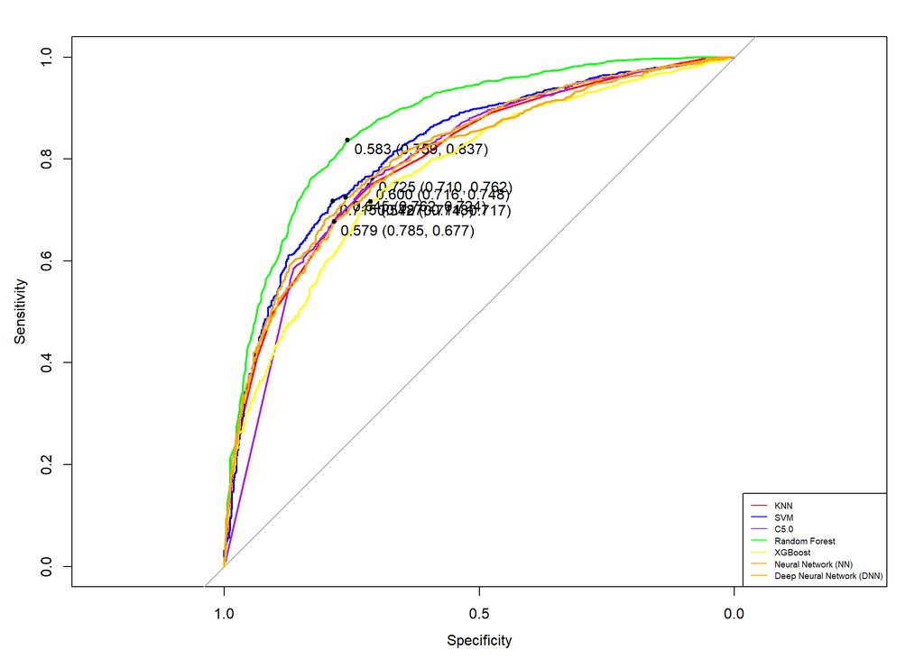

```r
# Load required packages
library(pROC)

# Create an empty plot with the first ROC curve
plot(roc.knn, col = "red", print.thres = TRUE)

# Add the other ROC curves to the same plot
plot(roc.svm, col = "blue", print.thres = TRUE, add = TRUE)
plot(roc.c50, col = "purple", print.thres = TRUE, add = TRUE)
plot(roc.rf, col = "green", print.thres = TRUE, add = TRUE)
plot(roc.xgb, col = "yellow", print.thres = TRUE, add = TRUE)
plot(roc.nn, col = "orange", print.thres = TRUE, add = TRUE)
plot(roc.dnn, col = "orange", print.thres = TRUE, add = TRUE)

# Add legend
legend("bottomright", legend = c("KNN", "SVM", "C5.0", "Random Forest", "XGBoost", "Neural Network (NN)", "Deep Neural Network (DNN)"),
       col = c("red", "blue", "purple", "green", "yellow", "orange", "orange"), lty = 1, cex = 0.6)
```

The best model that we will keep to go further into the analysis is the Random Forest, hence we shall take a look at the variable importance for this model:

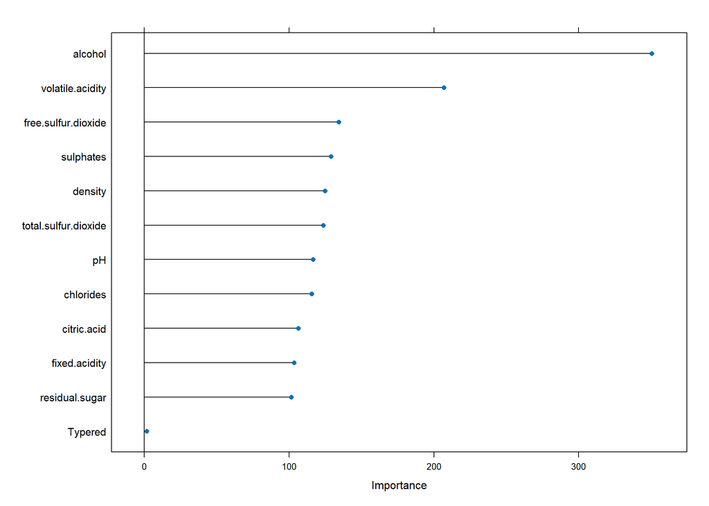

The most important features in this model are “alcohol”, “volatily.acid” and “free.sulfur.dioxide”.

## 6.9 Ensemble

Ensemble learning involves combining multiple classifiers to create a more robust meta-classifier. While highly effective, this approach can be computationally intensive, particularly when considering cost-sensitive learning.

To create an ensemble for classification, we utilize the mode function:

```r
mode <- function(v) {
  uniqv <- unique(v)
  uniqv[which.max(tabulate(match(v, uniqv)))]
}
```

### 6.9.1 Ensemble Prediction

To generate ensemble predictions, we apply the mode function across the predictions from individual classifiers, including KNN, SVM, and Random Forest:

```r
ensemble.pred = apply(data.frame(knnPred, svmPred, rfPred), 1, mode)
confusionMatrix(factor(ensemble.pred), testing_2$quality)
```

```
## Confusion Matrix and Statistics
##
##           Reference
## Prediction Regular Premium
##    Regular     467     160
##    Premium     403    1342
##
##                Accuracy : 0.7626
##                  95% CI : (0.745, 0.7796)
##     No Information Rate : 0.6332
##     P-Value [Acc > NIR] : < 2.2e-16
##
##                   Kappa : 0.4571
##
##  Mcnemar's Test P-Value : < 2.2e-16
##
##             Sensitivity : 0.5368
##             Specificity : 0.8935
##          Pos Pred Value : 0.7448
##          Neg Pred Value : 0.7691
##              Prevalence : 0.3668
##          Detection Rate : 0.1969
##    Detection Prevalence : 0.2643
##       Balanced Accuracy : 0.7151
##
##        'Positive' Class : Regular
##
```

## 6.10 Economic Function

In this analysis, we aimed to predict wine quality using machine learning models. We explored various models and evaluate their performance based on accuracy and ROC metrics.

Instead of focusing solely on traditional evaluation metrics, we will consider the cost implications associated with prediction errors. We will analyze it from a winery perspective, while it is generally perceived that producing high-quality (“Premium”) wine may involve higher costs due to factors like grape selection, fermentation techniques, aging processes, and quality control measures, the exact cost comparison between high-quality and non-high-quality (“Regular”) wine production can be complex and context-specific, in this project we will assume that the cost of producing wine is bigger for higher quality than lower quality. Predicting a high quality wine as a non high quality wine has an opportunity cost, this opportunity cost implies missing out the chance to sell a high quality one which sells as a higher price. Nevertheless, our major concern predicting wrong high quality wines, since higher quality implies higher earnings.

We construct a cost-sensitive matrix to quantify the costs associated with different prediction outcomes. Here’s the completed matrix:

| Prediction/Reference | not high quality (Regular) | High-Quality (Premium) |
| --- | --- | --- |
| Not high quality (Regular) | 0 | 0.5 |
| High-Quality (Premium) | 2 | 1 |

Here are the costs associated with each prediction outcome:

- Cost of false positives (predicting high-quality when it’s actually low-quality): $2
- Cost of false negatives (predicting low-quality when it’s actually high-quality): $0.5 opportunity cost of predicting wrong
- Cost of true positives: $1
- Cost of true negatives: $0

Threshold Analysis:

We’ll explore different thresholds using cross-validation to identify the threshold that minimizes the overall cost. Adjusting the threshold can help balance between false positives and false negatives based on cost implications.

Cost Calculation and Comparison:

After determining the optimal threshold for the model, we’ll calculate the cost of the final model and make prediction. The model with the lowest cost will be selected as the preferred option for predicting wine quality.

Overall, this approach aims to identify the cost-effectiveness of the model for predicting wine quality, considering the potential financial implications for wineries and consumer satisfaction.

Define first the specific function for the cost:

```r
Costfunction <- function(data, lev = NULL, model = NULL)
{
  y.pred = data$pred
  y.true = data$obs
  CM = confusionMatrix(y.pred, y.true)$table
  out = sum(cost.unit*CM)/sum(CM)
  names(out) <- c("Costfunction")
  out
}
```

Now include this function in the Caret control:

```r
ctrl <- trainControl(method = "cv", number = 5,
                     classProbs = TRUE,
                     summaryFunction = Costfunction,
                     verboseIter=F)
```

```r
# Define thresholds to test
thresholds <- seq(0.5, 0.9, 0.1)

# Initialize variables to store results
costs <- numeric(length(thresholds))

# Iterate over thresholds
for (i in seq_along(thresholds)) {
  # Make predictions using the current threshold
  RfProb <- predict(RfFit, testing_2, type = "prob")
  Rf.pred <- rep("Regular", nrow(testing_2))
  Rf.pred[which(RfProb[, 2] > thresholds[i])] <- "Premium"

  # Calculate confusion matrix
  CM <- confusionMatrix(factor(Rf.pred), testing_2$quality)$table

  # Calculate cost
  costs[i] <- sum(cost.unit * CM) / sum(CM)
}
# Find the index of the minimum cost
min_cost_index <- which.min(costs)

# Print the threshold and corresponding minimum cost
cat("Best Threshold:", thresholds[min_cost_index], "\n")
```

```
## Best Threshold: 0.9
```

```r
cat("Minimum Cost:", costs[min_cost_index], "\n")
```

```
## Minimum Cost: 0.4660624
```

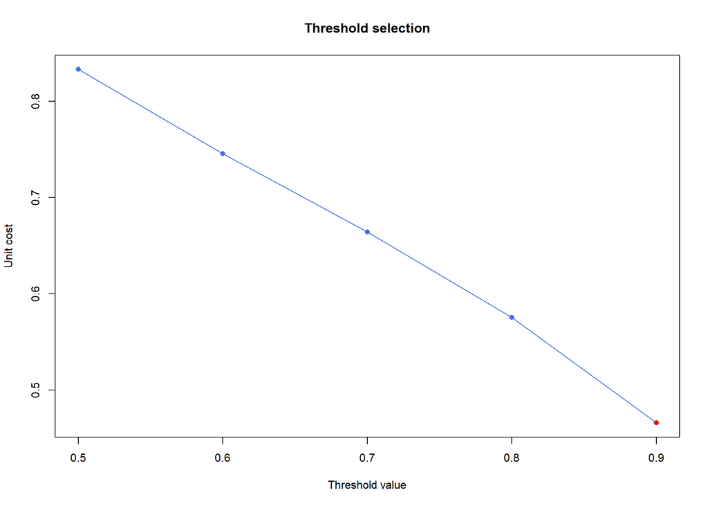

```r
# Plot threshold vs. cost
plot(thresholds, costs, type = "o", pch = 16, col = "royalblue2",
     xlab = "Threshold value", ylab = "Unit cost",
     main = "Threshold selection")

# Add point for minimum cost
points(thresholds[min_cost_index], costs[min_cost_index], col = "red", pch = 16)
```

### 6.10.1 Final prediction

After evaluating various thresholds and their corresponding costs, a final threshold of 0.9 was chosen for predicting wine quality using the Random Forest model. This threshold was selected based on its ability to minimize the overall cost associated with misclassifications.

Make final predictions for optimal treshold:

```r
threshold = 0.9
RfFinal <- train(quality ~.,
                  method = "rf",
                  data = training_2,
                  preProcess = c("center", "scale"),
                  ntree = 100,
                  cutoff=c(0.7,0.3),
                  tuneGrid = expand.grid(mtry=c(6,8,10)),
                  metric = "Costfunction",
                  maximize = F,
                  trControl = ctrl
                 )
RfProbfinal = predict(RfFinal, testing_2, type="prob")
FinalRfPred = rep("Regular", nrow(testing_2))
FinalRfPred[which(RfProbfinal[,2] > threshold)] = "Premium"
CM = confusionMatrix(factor(FinalRfPred), testing_2$quality)$table
cost = sum(as.vector(CM)*cost.unit)/sum(CM)
cost
```

```
## [1] 0.4597386
```

In summary, the final cost predicted with the best threshold provides the wine company with valuable insights into the economic implications of employing the machine learning model for wine quality assessment. By analyzing this cost alongside the total cost incurred in a month, the company can make informed decisions regarding resource allocation, model optimization, and business strategies to enhance operational efficiency and financial performance.

# 7 Conlclusion

From the results, we observed that the random forest model achieved the highest accuracy and AUC score among all models, indicating its superior discriminatory ability in distinguishing between Regular and Premium instances. However, it’s noteworthy that ensemble learning techniques combining multiple models did not outperform individual models in this scenario.

While it’s challenging to quantify the exact monetary value of improving quality predictions, the implications of accurate predictions are significant. Effective prediction tools can help in allocating resources efficiently, reducing costs associated with misclassifications, and ultimately improving overall product quality and customer satisfaction.